# Loan Predication

### Dataset Information

Dream Housing Finance company deals in all home loans. They have presence across all urban, semi urban and rural areas. Customer first apply for home loan after that company validates the customer eligibility for loan. Company wants to automate the loan eligibility process (real time) based on customer detail provided while filling online application form. These details are Gender, Marital Status, Education, Number of Dependents, Income, Loan Amount, Credit History and others. To automate this process, they have given a problem to identify the customers segments, those are eligible for loan amount so that they can specifically target these customers.

This is a standard supervised classification task.A classification problem where we have to predict whether a loan would be approved or not. Below is the dataset attributes with description.

DATASET :- https://www.kaggle.com/altruistdelhite04/loan-prediction-problem-dataset

```python
# Import Models
```

```python
import pandas as pd
import numpy as np
import seaborn as sns
import matplotlib.pyplot as plt
%matplotlib inline
```

```python
# Loading the DataSet
```

```python
path = "B:\DATA_SCIENCE\Data_Science_Material\HAND_on_Project\Beginner\Loan_Prediction\Loan_train_data.csv"
df = pd.read_csv(path)
df.head(5)
```

|  | Loan_ID | Gender | Married | Dependents | Education | Self_Employed | ApplicantIncome | CoapplicantIncome | LoanAmount | Loan_Amount_Term | Credit_History | Property_Area | Loan_Status |
| --- | --- | --- | --- | --- | --- | --- | --- | --- | --- | --- | --- | --- | --- |
| 0 | LP001002 | Male | No | 0 | Graduate | No | 5849 | 0.0 | NaN | 360.0 | 1.0 | Urban | Y |
| 1 | LP001003 | Male | Yes | 1 | Graduate | No | 4583 | 1508.0 | 128.0 | 360.0 | 1.0 | Rural | N |
| 2 | LP001005 | Male | Yes | 0 | Graduate | Yes | 3000 | 0.0 | 66.0 | 360.0 | 1.0 | Urban | Y |
| 3 | LP001006 | Male | Yes | 0 | Not Graduate | No | 2583 | 2358.0 | 120.0 | 360.0 | 1.0 | Urban | Y |
| 4 | LP001008 | Male | No | 0 | Graduate | No | 6000 | 0.0 | 141.0 | 360.0 | 1.0 | Urban | Y |

```python
df.describe()
```

|  | ApplicantIncome | CoapplicantIncome | LoanAmount | Loan_Amount_Term | Credit_History |
| --- | --- | --- | --- | --- | --- |
| count | 614.000000 | 614.000000 | 592.000000 | 600.00000 | 564.000000 |
| mean | 5403.459283 | 1621.245798 | 146.412162 | 342.00000 | 0.842199 |
| std | 6109.041673 | 2926.248369 | 85.587325 | 65.12041 | 0.364878 |
| min | 150.000000 | 0.000000 | 9.000000 | 12.00000 | 0.000000 |
| 25% | 2877.500000 | 0.000000 | 100.000000 | 360.00000 | 1.000000 |
| 50% | 3812.500000 | 1188.500000 | 128.000000 | 360.00000 | 1.000000 |
| 75% | 5795.000000 | 2297.250000 | 168.000000 | 360.00000 | 1.000000 |
| max | 81000.000000 | 41667.000000 | 700.000000 | 480.00000 | 1.000000 |

```python
df.info()
```

```
<class 'pandas.core.frame.DataFrame'>
RangeIndex: 614 entries, 0 to 613
Data columns (total 13 columns):
 #   Column             Non-Null Count  Dtype
---  ------             --------------  -----
 0   Loan_ID            614 non-null    object
 1   Gender             601 non-null    object
 2   Married            611 non-null    object
 3   Dependents         599 non-null    object
 4   Education          614 non-null    object
 5   Self_Employed      582 non-null    object
 6   ApplicantIncome    614 non-null    int64
 7   CoapplicantIncome  614 non-null    float64
 8   LoanAmount         592 non-null    float64
 9   Loan_Amount_Term   600 non-null    float64
 10  Credit_History     564 non-null    float64
 11  Property_Area      614 non-null    object
 12  Loan_Status        614 non-null    object
dtypes: float64(4), int64(1), object(8)
memory usage: 62.5+ KB
```

```python
df.columns
```

```
Index(['Loan_ID', 'Gender', 'Married', 'Dependents', 'Education',
       'Self_Employed', 'ApplicantIncome', 'CoapplicantIncome', 'LoanAmount',
       'Loan_Amount_Term', 'Credit_History', 'Property_Area', 'Loan_Status'],
      dtype='object')
```

###### Need to Convert all the object into Numerical category

```python
### Preprocessing the dataset
```

```python
# Find the null value
df.isnull().sum()
```

```
Loan_ID               0
Gender               13
Married               3
Dependents           15
Education             0
Self_Employed        32
ApplicantIncome       0
CoapplicantIncome     0
LoanAmount           22
Loan_Amount_Term     14
Credit_History       50
Property_Area         0
Loan_Status           0
dtype: int64
```

#### Fill the missing value for the numerical terms - Using Mean

As i you can check these below columns having missing values, which is int numeric form, so will fill all the value with mean(average) value

LoanAmount

Loan_Amount_Term

Credit_History

```python
df['LoanAmount'] = df['LoanAmount'].fillna(df['LoanAmount'].mean())
df['Loan_Amount_Term'] = df['Loan_Amount_Term'].fillna(df['Loan_Amount_Term'].mean())
df['Credit_History'] = df['Credit_History'].fillna(df['Credit_History'].mean())
```

##### Fill the missing value for the categorical terms - Using Mode (Most occuring(repeating) same values )

As you can see, below coulns are having categorical values, which can' be filled with numerical (mean) values, so we will put most repeated value using MODE fucntion

- Gender
- Married
- Dependents
- Self_Employed

```python
# As an example
df['Gender'].mode()
```

```
0    Male
dtype: object
```

```python
# If we want to get only male ecluding 0
df['Gender'].mode()[0]
```

```
'Male'
```

```python
df['Gender'] = df['Gender'].fillna(df['Gender'].mode()[0])
df['Married'] = df['Married'].fillna(df['Married'].mode()[0])
df['Dependents'] = df['Dependents'].fillna(df['Dependents'].mode()[0])
df['Self_Employed'] = df['Self_Employed'].fillna(df['Self_Employed'].mode()[0])
```

```python
df.isnull().sum()
```

```
Loan_ID              0
Gender               0
Married              0
Dependents           0
Education            0
Self_Employed        0
ApplicantIncome      0
CoapplicantIncome    0
LoanAmount           0
Loan_Amount_Term     0
Credit_History       0
Property_Area        0
Loan_Status          0
dtype: int64
```

#### Now we have no any null value in the dataset

## Exploratory Data Analysis

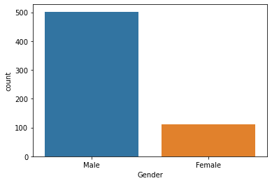

```python
# let's check the first male and female ratio
sns.countplot(df['Gender'])
```

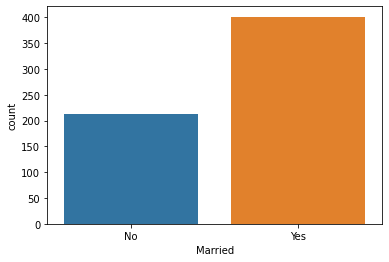

```python
sns.countplot(df['Married'])
```

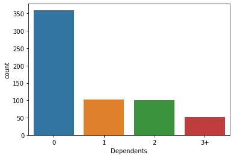

```python
sns.countplot(df['Dependents'])
```

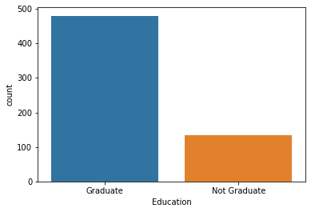

```python
sns.countplot(df['Education'])
```

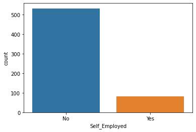

```python
sns.countplot(df['Self_Employed'])
```

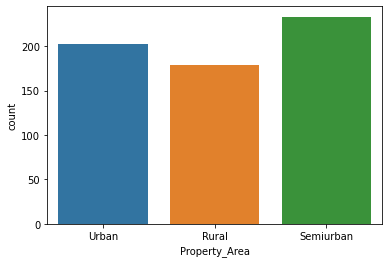

```python
sns.countplot(df['Property_Area'])
```

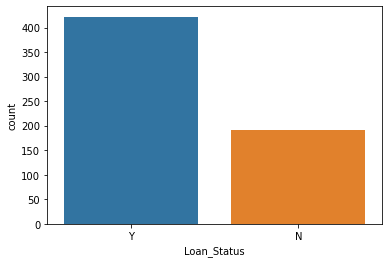

```python
sns.countplot(df['Loan_Status'])
```

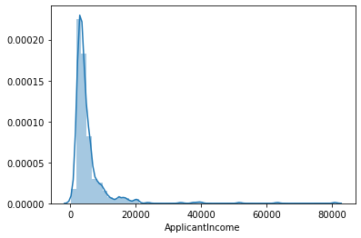

```python
# numerical attributes visualization
sns.distplot(df["ApplicantIncome"])
```

#### To nomalized the above graph in better plot, we can convert that into log file

# df['ApplicantIncome'] = np.log(df['ApplicantIncome'])

sns.distplot(df["ApplicantIncome"])

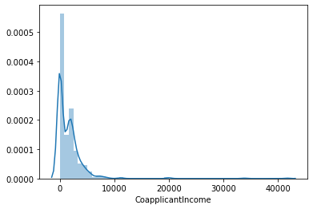

```python
sns.distplot(df["CoapplicantIncome"])
```

[output not shown]

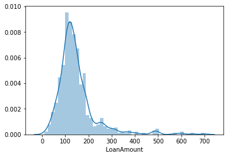

```python
sns.distplot(df["LoanAmount"])
```

[output not shown]

[output cut: 10 more lines]

[output not shown]

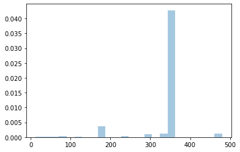

```python
sns.distplot(df['Loan_Amount_Term'])
```

[output not shown]

[output cut: 10 more lines]

[output not shown]

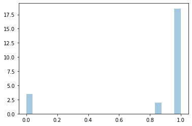

```python
sns.distplot(df['Credit_History'])
```

# Feature Scaling

### Creation of new attributes

```python
# total income
df['Total_Income'] = df['ApplicantIncome'] + df['CoapplicantIncome']
df.head()
```

|  | Loan_ID | Gender | Married | Dependents | Education | Self_Employed | ApplicantIncome | CoapplicantIncome | LoanAmount | Loan_Amount_Term | Credit_History | Property_Area | Loan_Status | Total_Income |
| --- | --- | --- | --- | --- | --- | --- | --- | --- | --- | --- | --- | --- | --- | --- |
| 0 | LP001002 | Male | No | 0 | Graduate | No | 5849 | 0.0 | 146.412162 | 360.0 | 1.0 | Urban | Y | 5849.0 |
| 1 | LP001003 | Male | Yes | 1 | Graduate | No | 4583 | 1508.0 | 128.000000 | 360.0 | 1.0 | Rural | N | 6091.0 |
| 2 | LP001005 | Male | Yes | 0 | Graduate | Yes | 3000 | 0.0 | 66.000000 | 360.0 | 1.0 | Urban | Y | 3000.0 |
| 3 | LP001006 | Male | Yes | 0 | Not Graduate | No | 2583 | 2358.0 | 120.000000 | 360.0 | 1.0 | Urban | Y | 4941.0 |
| 4 | LP001008 | Male | No | 0 | Graduate | No | 6000 | 0.0 | 141.000000 | 360.0 | 1.0 | Urban | Y | 6000.0 |

```python
df2 = df
```

```python
df2.head()
```

|  | Loan_ID | Gender | Married | Dependents | Education | Self_Employed | ApplicantIncome | CoapplicantIncome | LoanAmount | Loan_Amount_Term | Credit_History | Property_Area | Loan_Status | Total_Income |
| --- | --- | --- | --- | --- | --- | --- | --- | --- | --- | --- | --- | --- | --- | --- |
| 0 | LP001002 | Male | No | 0 | Graduate | No | 5849 | 0.0 | 146.412162 | 360.0 | 1.0 | Urban | Y | 5849.0 |
| 1 | LP001003 | Male | Yes | 1 | Graduate | No | 4583 | 1508.0 | 128.000000 | 360.0 | 1.0 | Rural | N | 6091.0 |
| 2 | LP001005 | Male | Yes | 0 | Graduate | Yes | 3000 | 0.0 | 66.000000 | 360.0 | 1.0 | Urban | Y | 3000.0 |
| 3 | LP001006 | Male | Yes | 0 | Not Graduate | No | 2583 | 2358.0 | 120.000000 | 360.0 | 1.0 | Urban | Y | 4941.0 |
| 4 | LP001008 | Male | No | 0 | Graduate | No | 6000 | 0.0 | 141.000000 | 360.0 | 1.0 | Urban | Y | 6000.0 |

## Now We will do Log Transfomation

Log transformation is a data transformation method in which it replaces each variable x with a log(x). Log transformation is a data transformation method in which it replaces each variable x with a log(x).

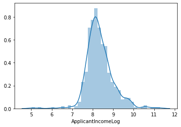

```python
# apply log transformation to the attribute
df2['ApplicantIncomeLog'] = np.log(df2['ApplicantIncome'])
sns.distplot(df2["ApplicantIncomeLog"])
```

[output not shown]

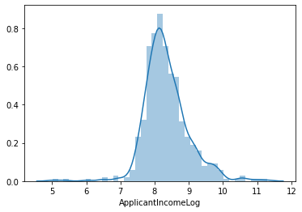

```python
df2['CoapplicantIncomeLog'] = np.log(df2['CoapplicantIncome'])
sns.distplot(df2["ApplicantIncomeLog"])
```

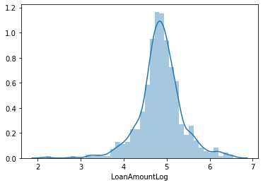

```python
df2['LoanAmountLog'] = np.log(df2['LoanAmount'])
sns.distplot(df2["LoanAmountLog"])
```

[output not shown]

[output cut: 11 more lines]

[output not shown]

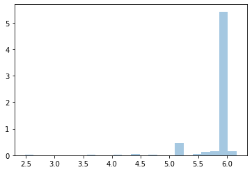

```python
df2['Loan_Amount_Term_Log'] = np.log(df2['Loan_Amount_Term'])
sns.distplot(df2["Loan_Amount_Term_Log"])
```

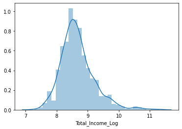

```python
df2['Total_Income_Log'] = np.log(df2['Total_Income'])
sns.distplot(df2["Total_Income_Log"])
```

# Correlation Matrix

Correlation is essentially a measure of how closely two variables are related to each other. ... It estimates the strength or direction between two or more variables that have a linear relationship. The Pearson correlation measures the linear relationship between two variables.

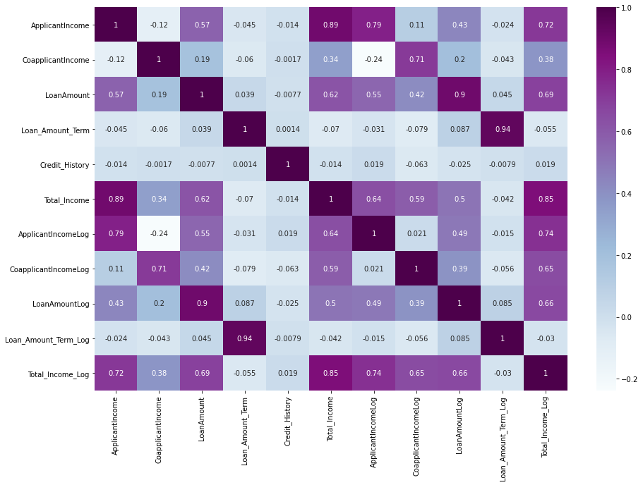

```python
corr = df2.corr()
plt.figure(figsize = (15, 10))
sns.heatmap(corr, annot= True, cmap = "BuPu")
```

```python
df2.head(5)
```

|  | Loan_ID | Gender | Married | Dependents | Education | Self_Employed | ApplicantIncome | CoapplicantIncome | LoanAmount | Loan_Amount_Term | Credit_History | Property_Area | Loan_Status | Total_Income | ApplicantIncomeLog | CoapplicantIncomeLog | LoanAmountLog | Loan_Amount_Term_Log | Total_Income_Log |
| --- | --- | --- | --- | --- | --- | --- | --- | --- | --- | --- | --- | --- | --- | --- | --- | --- | --- | --- | --- |
| 0 | LP001002 | Male | No | 0 | Graduate | No | 5849 | 0.0 | 146.412162 | 360.0 | 1.0 | Urban | Y | 5849.0 | 8.674026 | -inf | 4.986426 | 5.886104 | 8.674026 |
| 1 | LP001003 | Male | Yes | 1 | Graduate | No | 4583 | 1508.0 | 128.000000 | 360.0 | 1.0 | Rural | N | 6091.0 | 8.430109 | 7.318540 | 4.852030 | 5.886104 | 8.714568 |
| 2 | LP001005 | Male | Yes | 0 | Graduate | Yes | 3000 | 0.0 | 66.000000 | 360.0 | 1.0 | Urban | Y | 3000.0 | 8.006368 | -inf | 4.189655 | 5.886104 | 8.006368 |
| 3 | LP001006 | Male | Yes | 0 | Not Graduate | No | 2583 | 2358.0 | 120.000000 | 360.0 | 1.0 | Urban | Y | 4941.0 | 7.856707 | 7.765569 | 4.787492 | 5.886104 | 8.505323 |
| 4 | LP001008 | Male | No | 0 | Graduate | No | 6000 | 0.0 | 141.000000 | 360.0 | 1.0 | Urban | Y | 6000.0 | 8.699515 | -inf | 4.948760 | 5.886104 | 8.699515 |

```python
# drop unnecessary columns
cols = ['ApplicantIncome', 'CoapplicantIncome', "LoanAmount", "Loan_Amount_Term", "Total_Income", 'Loan_ID', 'CoapplicantIncomeLog']
df2 = df2.drop(columns=cols, axis=1)
df2.head()
```

|  | Gender | Married | Dependents | Education | Self_Employed | Credit_History | Property_Area | Loan_Status | ApplicantIncomeLog | LoanAmountLog | Loan_Amount_Term_Log | Total_Income_Log |
| --- | --- | --- | --- | --- | --- | --- | --- | --- | --- | --- | --- | --- |
| 0 | Male | No | 0 | Graduate | No | 1.0 | Urban | Y | 8.674026 | 4.986426 | 5.886104 | 8.674026 |
| 1 | Male | Yes | 1 | Graduate | No | 1.0 | Rural | N | 8.430109 | 4.852030 | 5.886104 | 8.714568 |
| 2 | Male | Yes | 0 | Graduate | Yes | 1.0 | Urban | Y | 8.006368 | 4.189655 | 5.886104 | 8.006368 |
| 3 | Male | Yes | 0 | Not Graduate | No | 1.0 | Urban | Y | 7.856707 | 4.787492 | 5.886104 | 8.505323 |
| 4 | Male | No | 0 | Graduate | No | 1.0 | Urban | Y | 8.699515 | 4.948760 | 5.886104 | 8.699515 |

# label Encoding

Label Encoding refers to converting the labels into numeric form so as to convert it into the machine-readable form.

#### Two Type of encoding

- Nominal Encoding ( One -HOT Encoding, Mean Encoding etc) In this encoding, we deal with the small categorical features to convert that all into (0,1) form only
- Ordinal Encoding ( Label Encoding, Target Guided Ordinal Encoding) In this encoding, we deal with large number of categorical features, wherein we will convert all into rank series (01,1,2,3,....so on), allocate rank to all features

```python
from sklearn.preprocessing import LabelEncoder
cols = ['Gender',"Married","Education",'Self_Employed',"Property_Area","Loan_Status","Dependents"]
LE = LabelEncoder()
for col in cols:
    df2[col] = LE.fit_transform(df2[col])
```

```python
df2.head()
```

|  | Gender | Married | Dependents | Education | Self_Employed | Credit_History | Property_Area | Loan_Status | ApplicantIncomeLog | LoanAmountLog | Loan_Amount_Term_Log | Total_Income_Log |
| --- | --- | --- | --- | --- | --- | --- | --- | --- | --- | --- | --- | --- |
| 0 | 1 | 0 | 0 | 0 | 0 | 1.0 | 2 | 1 | 8.674026 | 4.986426 | 5.886104 | 8.674026 |
| 1 | 1 | 1 | 1 | 0 | 0 | 1.0 | 0 | 0 | 8.430109 | 4.852030 | 5.886104 | 8.714568 |
| 2 | 1 | 1 | 0 | 0 | 1 | 1.0 | 2 | 1 | 8.006368 | 4.189655 | 5.886104 | 8.006368 |
| 3 | 1 | 1 | 0 | 1 | 0 | 1.0 | 2 | 1 | 7.856707 | 4.787492 | 5.886104 | 8.505323 |
| 4 | 1 | 0 | 0 | 0 | 0 | 1.0 | 2 | 1 | 8.699515 | 4.948760 | 5.886104 | 8.699515 |

```python
# Let's drop the Loan_Status, because it is not now important for model prediction
df3 = df2.drop(columns = ['Loan_Status'], axis = 1)
df3.head(5)
```

|  | Gender | Married | Dependents | Education | Self_Employed | Credit_History | Property_Area | ApplicantIncomeLog | LoanAmountLog | Loan_Amount_Term_Log | Total_Income_Log |
| --- | --- | --- | --- | --- | --- | --- | --- | --- | --- | --- | --- |
| 0 | 1 | 0 | 0 | 0 | 0 | 1.0 | 2 | 8.674026 | 4.986426 | 5.886104 | 8.674026 |
| 1 | 1 | 1 | 1 | 0 | 0 | 1.0 | 0 | 8.430109 | 4.852030 | 5.886104 | 8.714568 |
| 2 | 1 | 1 | 0 | 0 | 1 | 1.0 | 2 | 8.006368 | 4.189655 | 5.886104 | 8.006368 |
| 3 | 1 | 1 | 0 | 1 | 0 | 1.0 | 2 | 7.856707 | 4.787492 | 5.886104 | 8.505323 |
| 4 | 1 | 0 | 0 | 0 | 0 | 1.0 | 2 | 8.699515 | 4.948760 | 5.886104 | 8.699515 |

# Model Implementation

### Train_Test_Split

Now we have df3 ( All are Indepedant variable ), and df2['Loan_Status'] is dependant variable

```python
X = df3
y = df2['Loan_Status']
```

```python
from sklearn.model_selection import train_test_split
x_train, x_test, y_train, y_test = train_test_split(X, y, test_size=0.25, random_state=42)
```

```python
print (x_train.shape)
print (x_test.shape)
print (y_train.shape)
print (y_test.shape)
```

```
(460, 11)
(154, 11)
(460,)
(154,)
```

# Model Training

Let's check in the different way with different model

```python
# Firstly let's load all the model
from sklearn.linear_model import LogisticRegression
from sklearn.tree import DecisionTreeClassifier
from sklearn.ensemble import RandomForestClassifier
from sklearn.ensemble import ExtraTreesClassifier
```

```python
# Now let's take all the model into list
models = []
models.append(('Logostic Regression', LogisticRegression()))
models.append(('Decision Tree Classifier', DecisionTreeClassifier()))
models.append(('RandomForestClassifier', RandomForestClassifier()))
models.append(('ExtraTreesClassifier', ExtraTreesClassifier()))

# Evalute each model in turn
from sklearn.model_selection import KFold
from sklearn.model_selection import cross_val_score
results = []
names = []

for name, model in models:
    kfold = KFold(n_splits = 10, random_state = 42)
    cv_results = cross_val_score(model, x_train, y_train, cv = kfold, scoring = 'accuracy')
    results.append(cv_results)
    names.append(name)
    msg = "%s: %f (%f)" % (name, cv_results.mean(), cv_results.std())
    print(msg)
```

[output not shown]

```
Logostic Regression: 0.821739 (0.052174)
Decision Tree Classifier: 0.734783 (0.068608)
RandomForestClassifier: 0.804348 (0.049573)
```

[output not shown]

```
ExtraTreesClassifier: 0.782609 (0.037653)
```

```python
# classify function
def classify(model, x, y):
    x_train, x_test, y_train, y_test = train_test_split(X, y, test_size=0.25, random_state=42)
    model.fit(x_train, y_train)
    print("Accuracy is", model.score(x_test, y_test)*100)
    # cross validation - it is used for better validation of model
    # eg: cv-5, train-4, test-1
    score = cross_val_score(model, x, y, cv=5)
    print("Cross validation is",np.mean(score)*100)
```

```python
from sklearn.linear_model import LogisticRegression
model = LogisticRegression()
classify(model, X, y)
```

```
Accuracy is 77.27272727272727
Cross validation is 80.9462881514061
```

```python
model = RandomForestClassifier()
classify(model, X, y)
```

```
Accuracy is 77.27272727272727
Cross validation is 78.83513261362121
```

```python
model = ExtraTreesClassifier()
classify(model, X, y)
```

```
Accuracy is 71.42857142857143
Cross validation is 77.04118352658936
```

# Model deployement

```python
model = RandomForestClassifier()
model.fit(x_train, y_train)
```

```
RandomForestClassifier(bootstrap=True, ccp_alpha=0.0, class_weight=None,
                       criterion='gini', max_depth=None, max_features='auto',
                       max_leaf_nodes=None, max_samples=None,
                       min_impurity_decrease=0.0, min_impurity_split=None,
                       min_samples_leaf=1, min_samples_split=2,
                       min_weight_fraction_leaf=0.0, n_estimators=100,
                       n_jobs=None, oob_score=False, random_state=None,
                       verbose=0, warm_start=False)
```

```python
y_pred = model.predict(x_test)
y_pred
```

```
array([1, 1, 1, 1, 1, 1, 1, 1, 1, 1, 0, 1, 1, 1, 1, 1, 1, 1, 1, 1, 1, 1,
       1, 1, 1, 1, 1, 1, 1, 1, 1, 1, 1, 1, 1, 0, 1, 1, 1, 1, 1, 1, 1, 1,
       1, 1, 1, 0, 0, 0, 1, 1, 0, 1, 1, 1, 1, 1, 0, 1, 0, 1, 0, 1, 1, 1,
       1, 1, 1, 1, 0, 1, 1, 1, 0, 0, 1, 0, 0, 1, 1, 1, 1, 1, 1, 1, 1, 0,
       1, 1, 1, 0, 0, 1, 1, 1, 1, 1, 1, 1, 1, 1, 1, 1, 1, 0, 1, 0, 1, 1,
       1, 0, 1, 1, 0, 1, 1, 1, 1, 1, 1, 1, 1, 1, 1, 1, 1, 0, 0, 1, 0, 1,
       1, 0, 1, 1, 1, 1, 1, 1, 1, 1, 0, 0, 1, 1, 1, 1, 1, 1, 1, 1, 0, 1])
```

## Confusion Matrix

A confusion matrix is a summary of prediction results on a classification problem. The number of correct and incorrect predictions are summarized with count values and broken down by each class. It gives us insight not only into the errors being made by a classifier but more importantly the types of errors that are being made.

```python
# Let check the value with Random Predicted information
from sklearn.metrics import confusion_matrix
cm = confusion_matrix(y_test, y_pred)
cm
```

```
array([[24, 30],
       [ 4, 96]], dtype=int64)
```

```python
# Let's check the accuracy of model
from sklearn.metrics import accuracy_score
accuracy_score(y_test, y_pred)
```

```
0.7792207792207793
```

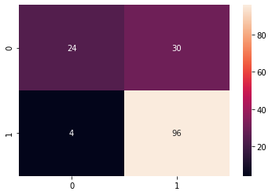

```python
sns.heatmap(cm, annot=True)
```